# Assignment10

Anna Lisa and Wenjia

2023-06-29

## Task 1: Biological networks

```r
head(YEASTRACT)
```

```
##   YKL112W ABF1   snR44 SNR44 X27016735 X2016.Jul.27
## 1 YKL112W ABF1 YAL003W  EFB1  20385592     2010 Aug
## 2 YKL112W ABF1 YAL003W  EFB1  28158860   2017 May 5
## 3 YKL112W ABF1 YAL007C  ERP2  20385592     2010 Aug
## 4 YKL112W ABF1 YAL008W FUN14  20385592     2010 Aug
## 5 YKL112W ABF1 YAL012W  CYS3  20385592     2010 Aug
## 6 YKL112W ABF1 YAL017W  PSK1  20385592     2010 Aug
##   Unstressed.log.phase.growth..control. Positive   Direct
## 1 Unstressed log-phase growth (control) Positive Indirect
## 2 Unstressed log-phase growth (control)      N/A   Direct
## 3 Unstressed log-phase growth (control) Positive Indirect
## 4 Unstressed log-phase growth (control) Positive Indirect
## 5 Unstressed log-phase growth (control) Positive Indirect
## 6 Unstressed log-phase growth (control) Positive Indirect
##              RT.PCR...wt.vs.TFBS.mutant
## 1 Microarray analysis - wt vs TF mutant
## 2                              ChIP-seq
## 3 Microarray analysis - wt vs TF mutant
## 4 Microarray analysis - wt vs TF mutant
## 5 Microarray analysis - wt vs TF mutant
## 6 Microarray analysis - wt vs TF mutant
```

```r
new_names <- c( "Regulator systematic", "Regulator standard", "Target systematic", "Target standard", "Id", "Date", "Environment", "Regulation", "Type", "Method")
colnames(YEASTRACT) <- new_names
head(YEASTRACT)
```

```
##   Regulator systematic Regulator standard Target systematic Target standard
## 1              YKL112W               ABF1           YAL003W            EFB1
## 2              YKL112W               ABF1           YAL003W            EFB1
## 3              YKL112W               ABF1           YAL007C            ERP2
## 4              YKL112W               ABF1           YAL008W           FUN14
## 5              YKL112W               ABF1           YAL012W            CYS3
## 6              YKL112W               ABF1           YAL017W            PSK1
##         Id       Date                           Environment Regulation     Type
## 1 20385592   2010 Aug Unstressed log-phase growth (control)   Positive Indirect
## 2 28158860 2017 May 5 Unstressed log-phase growth (control)        N/A   Direct
## 3 20385592   2010 Aug Unstressed log-phase growth (control)   Positive Indirect
## 4 20385592   2010 Aug Unstressed log-phase growth (control)   Positive Indirect
## 5 20385592   2010 Aug Unstressed log-phase growth (control)   Positive Indirect
## 6 20385592   2010 Aug Unstressed log-phase growth (control)   Positive Indirect
##                                  Method
## 1 Microarray analysis - wt vs TF mutant
## 2                              ChIP-seq
## 3 Microarray analysis - wt vs TF mutant
## 4 Microarray analysis - wt vs TF mutant
## 5 Microarray analysis - wt vs TF mutant
## 6 Microarray analysis - wt vs TF mutant
```

## 1. How many transcription factors/target genes are included in the file?

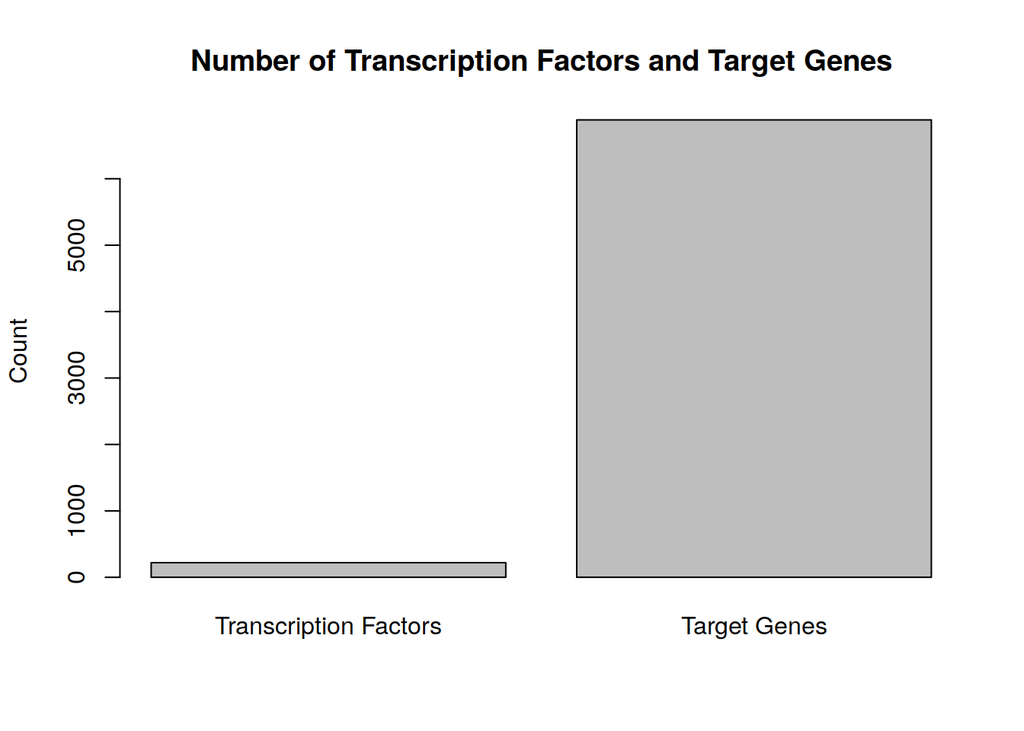

```r
regulators <- YEASTRACT$`Regulator systematic`
targets <- YEASTRACT$`Target systematic`

num_transcription_factors <- length(unique(regulators))
num_target_genes <- length(unique(targets))

barplot(c(num_transcription_factors, num_target_genes),
        names.arg = c("Transcription Factors", "Target Genes"),
        ylab = "Count",
        main = "Number of Transcription Factors and Target Genes")
```

## 2. How are the edges described, and how many of them are redundant?

```r
# Combine regulator and target to create unique edge identifiers
edges <- paste(regulators, targets, sep = "-")

# Count the total number of edges
total_edges <- length(edges)

# Identify duplicate edges
redundant_edges <- sum(duplicated(edges))

# Calculate the number of non-redundant edges
non_redundant_edges <- total_edges - redundant_edges

# Print the results
print(paste("Total Edges:", total_edges))
```

```
## [1] "Total Edges: 315496"
```

```r
print(paste("Redundant Edges:", redundant_edges))
```

```
## [1] "Redundant Edges: 119999"
```

```r
print(paste("Non-Redundant Edges:", non_redundant_edges))
```

```
## [1] "Non-Redundant Edges: 195497"
```

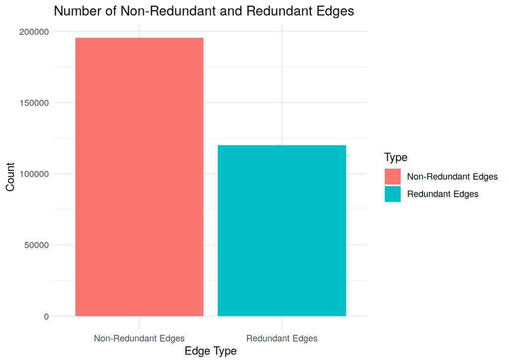

```r
edge_data <- data.frame(Type = c("Non-Redundant Edges", "Redundant Edges"),
                        Count = c(non_redundant_edges, redundant_edges))

# Create the ggplot
ggplot(edge_data, aes(x = Type, y = Count, fill = Type)) +
  geom_bar(stat = "identity", position = "dodge") +
  labs(title = "Number of Non-Redundant and Redundant Edges",
       x = "Edge Type",
       y = "Count") +
  theme_minimal()
```

## 3. How many targets are associated with each transcription factor? How many transcription factors are associated with each target?

```r
YEASTRACT %>%
  group_by(`Regulator systematic`) %>%
  summarize(targets = n_distinct(`Target systematic`)) %>%
  head()
```

```
## # A tibble: 6 × 2
##   `Regulator systematic` targets
##   <chr>                    <int>
## 1 MALR                         2
## 2 YAL051W                    921
## 3 YBL005W                   5996
## 4 YBL021C                    298
## 5 YBL054W                    100
## 6 YBL066C                    252
```

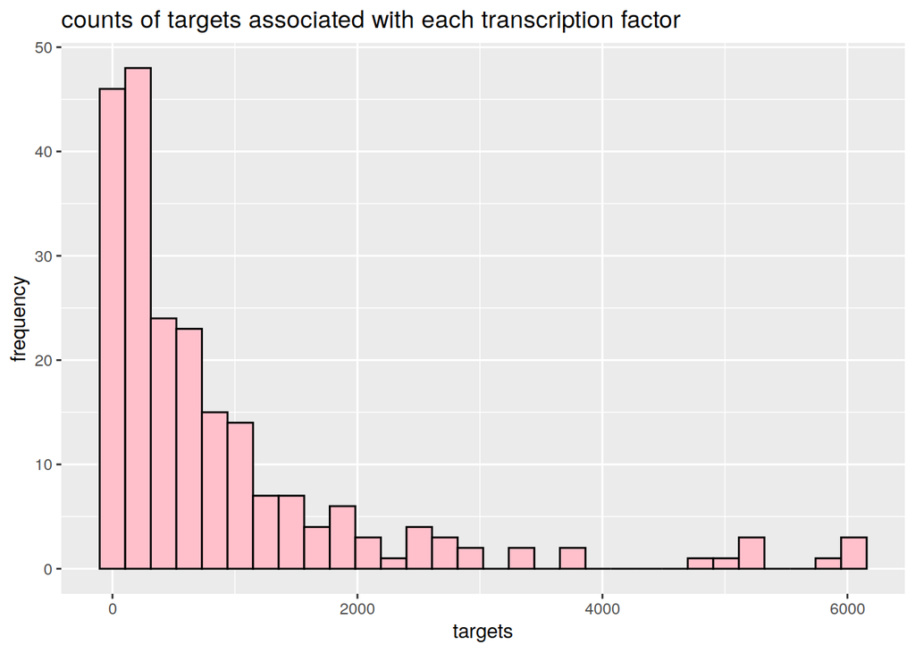

```r
YEASTRACT %>%
  group_by(`Regulator systematic`) %>%
  summarize(targets = n_distinct(`Target systematic`)) %>%
  ungroup() %>%
  as.data.frame() %>%
  ggplot() +
  geom_histogram(aes(x = targets), fill = "pink", colour = "black") +
  ggtitle("counts of targets associated with each transcription factor") +
  ylab("frequency")
```

```r
YEASTRACT %>%
  group_by(`Target systematic`) %>%
  summarize(transcription_factors = n_distinct(`Regulator systematic`)) %>%
  head()
```

```
## # A tibble: 6 × 2
##   `Target systematic` transcription_factors
##   <chr>                               <int>
## 1 A1                                      5
## 2 A2                                      1
## 3 ALD1                                    6
## 4 DEX2                                    6
## 5 HRA1                                    1
## 6 ICR1                                    1
```

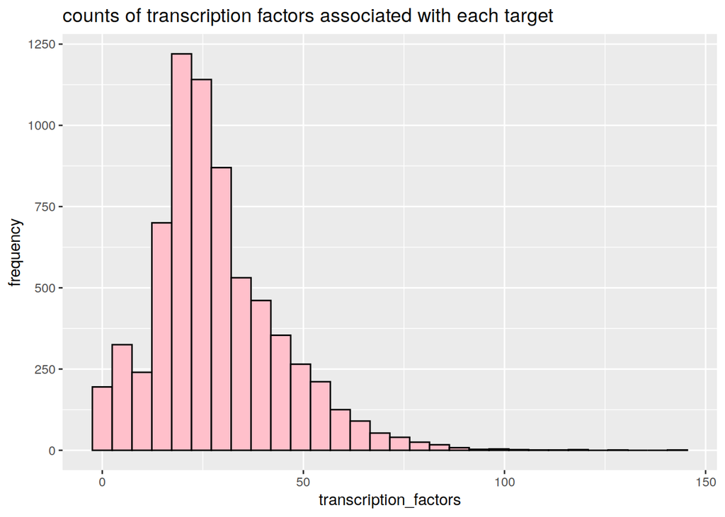

```r
YEASTRACT %>%
  group_by(`Target systematic`) %>%
  summarize(transcription_factors = n_distinct(`Regulator systematic`)) %>%
  ungroup() %>%
  as.data.frame() %>%
  ggplot() +
  geom_histogram(aes(x = transcription_factors), fill = "pink", colour = "black") +
  ggtitle("counts of transcription factors associated with each target") +
  ylab("frequency")
```

## 4. What is the timeframe of the data? Show a histogram.

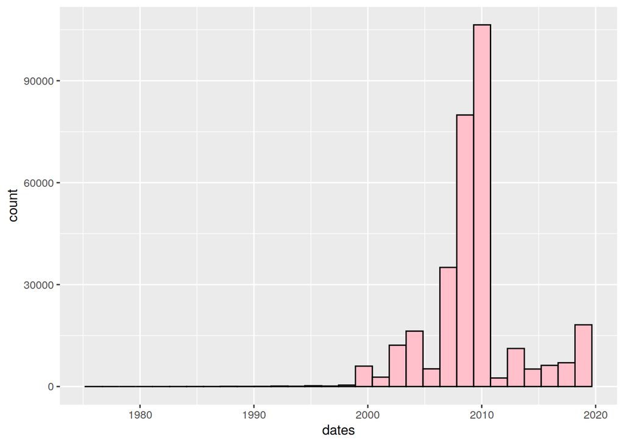

```r
dates = YEASTRACT$Date
dates <- as.Date(dates, format = c("%Y"))
dates <- as.data.frame(dates)
ggplot(dates, aes(x=dates)) + geom_histogram(fill = "pink", colour = "black")
```

## 5. Display the distribution of the columns ’Environment’, ’Regulation’, ’Type’, and ’Method’. Research these attributes on the internet to find more information about their values.

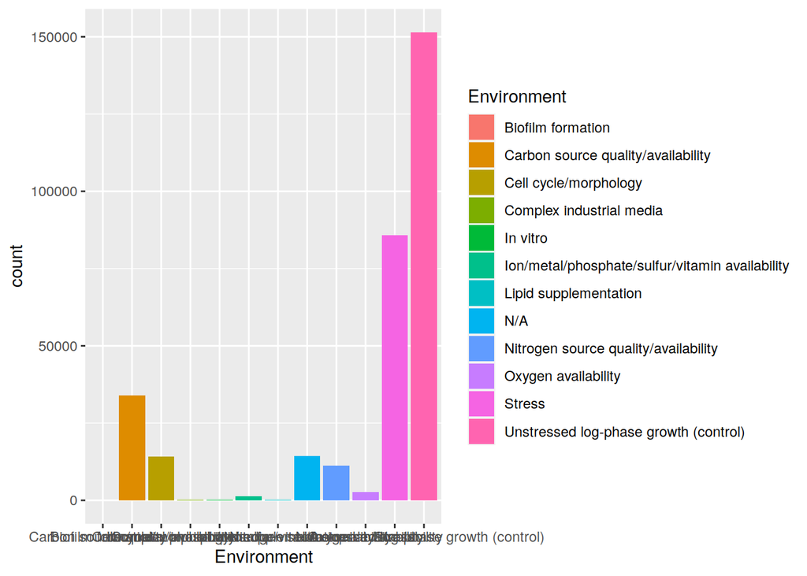

```r
environment <-
  YEASTRACT %>%
  group_by(Environment) %>%
  summarise(count = n())

ggplot(environment, aes(Environment, count, fill = Environment)) +
  geom_bar(stat = 'identity')
```

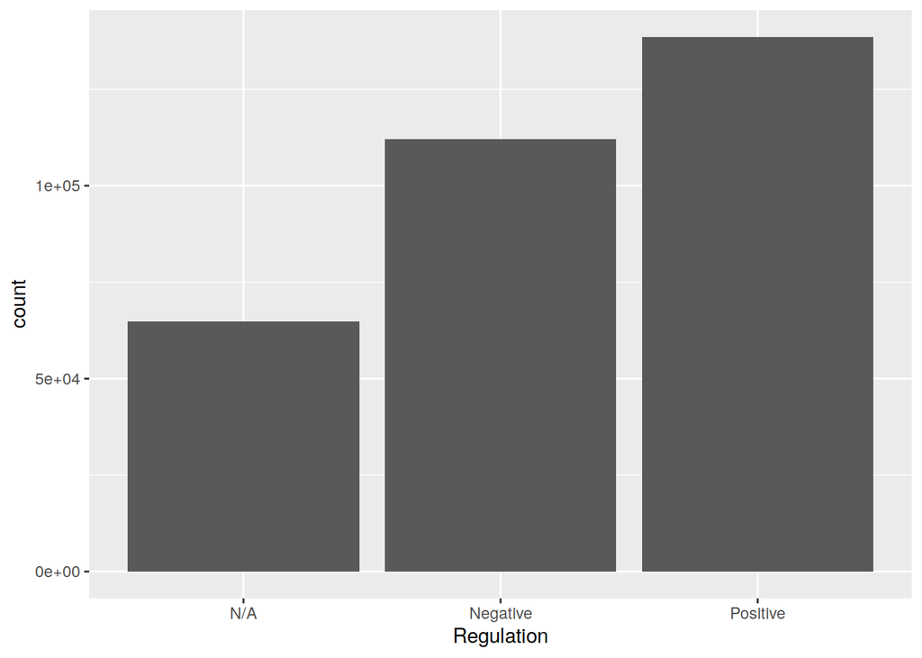

```r
regulation <-
  YEASTRACT %>%
  group_by(Regulation) %>%
  summarise(count = n())

ggplot(regulation, aes(Regulation, count)) +
    geom_bar(stat = 'identity')
```

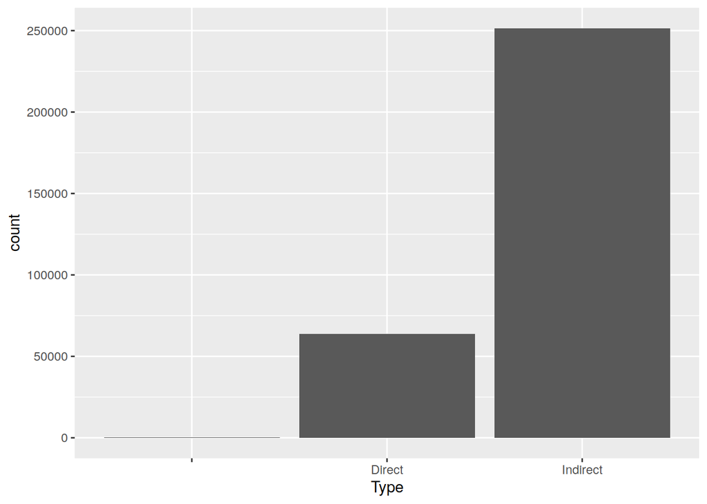

```r
type <-
  YEASTRACT %>%
  group_by(Type) %>%
  summarise(count = n())

ggplot(type, aes(Type, count)) +
    geom_bar(stat = 'identity')
```

[figure not shown]

```r
method <-
  YEASTRACT %>%
  group_by(Method) %>%
  summarise(count = n())

ggplot(method, aes(Method, count)) +
    geom_bar(stat = 'identity')
```

## MSMB 04

```r
coinflips = (runif(10000) > 0.5)
table(coinflips)
```

```
## coinflips
## FALSE  TRUE
##  5011  4989
```

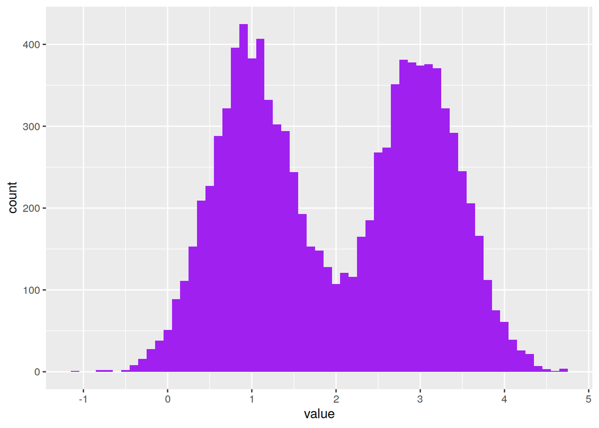

```r
oneFlip = function(fl, mean1 = 1, mean2 = 3, sd1 = 0.5, sd2 = 0.5) {
  if (fl) {
   rnorm(1, mean1, sd1)
  } else {
   rnorm(1, mean2, sd2)
  }
}
fairmix = vapply(coinflips, oneFlip, numeric(1))
library("ggplot2")
library("dplyr")
ggplot(tibble(value = fairmix), aes(x = value)) +
     geom_histogram(fill = "purple", binwidth = 0.1)
```

## What does the EM-Algorithm do ?

The Expectation-Maximization (EM) algorithm is a statistical method used to estimate parameters in models with unobserved or missing data. It is particularly useful when dealing with problems involving incomplete or latent variables. The algorithm iteratively maximizes a likelihood function to estimate the parameters of interest

## What mathematical background is used

1. Maximum Likelihood Estimation (MLE) –> explained in our presentation a few weeks ago

   -MLE is a method for estimating the parameters of a statistical model by maximizing the likelihood function. The likelihood function measures the probability of observing the given data as a function of the model parameters.

   -The goal of MLE is to find the parameter values that maximize the likelihood function, making the observed data most likely under the assumed model
2. Latent Variables

   -Latent variables are unobserved or hidden variables in a statistical model. They are not directly measured or observed but are inferred from other variables.

   -Latent variables are often used to represent underlying concepts or processes that are not directly measurable. For example, in clustering problems, the latent variables represent the unknown cluster assignments of data points.
3. It is used with Hidden Markov models, where the unobserved data would be the states within the underlying Markov chain

## EM algorithm step by step:

## Step 1: Initialization

```
-   Start with initial guesses for the model parameters.
-   These initial parameter values can be randomly chosen or based
    on some prior knowledge.
```

Step 2: Expectation Step (E):

- algorithm computes the expected values of the latent variables given the observed data and the current parameter estimates

- calculates the probabilities or posterior distributions of the latent variables using the current parameter values and the observed data

Step 3: Maximization Step (M):

- algorithm updates the parameter estimates by maximizing the expected log-likelihood (ELL) computed in the E-step

- finds the parameter values that maximize the ELL, treating the expected values of the latent variables as complete data

Step 4: Iteration:

- Repeat the E-step and M-step until convergence is reached

## Discuss one example of EM-algorithm:

From EiB 2 –> On closer inspection, you notice that the GC content of the sequences varies greatly. In reviewing their experiment, you find that the Petri dish was contaminated by another bacterium. Now you do not know from which bacterium the measured sequences originate. Use the EM algorithm to estimate the maximum likelihoods A and B of both genomes. Choose starting value 𝜃 A = 0.4 and 𝜃B = 0.6. Since the growth rate of both bacterial strains is approximately identical, you can assume that cells of both bacterial species occur equally frequently in the Petri dish.

Note: In the expectation step, the conditional probability P (A|k) for a sequence of bacterium A is calculated using k nucleotides from {G, C}. The probability of P (k|A) can be calculated here using the binomial distribution B (𝜃, n, k).

```r
# E-STEP
calculate_conditional_probabilities <- function(sequences, thetaA, thetaB) {
  conditional_probs <- list()

  for (sequence in sequences) {
    n <- nchar(sequence)
    k <- sum(strsplit(sequence, "")[[1]] %in% c('G', 'C'))

    PA_k <- dbinom(k, n, thetaA)
    PB_k <- dbinom(k, n, thetaB)

    conditional_probs[[sequence]] <- list(PA_k = PA_k, PB_k = PB_k)
  }

  return(conditional_probs)
}

# M-STEP
# --> multiplying the k with the conditional probabilities and dividing the sum by(sum total counts multiplied with conditional probabilities)

update_maximum_likelihoods <- function(sequences, conditional_probs) {
  sumPA_k <- 0
  sumPB_k <- 0
  sumPA_total <- 0
  sumPB_total <- 0

  for (sequence in sequences) {
    n <- nchar(sequence)
    k <- sum(strsplit(sequence, "")[[1]] %in% c('G', 'C'))

    sumPA_k <- sumPA_k + k * conditional_probs[[sequence]]$PA_k
    sumPB_k <- sumPB_k + k * conditional_probs[[sequence]]$PB_k
    sumPA_total <- sumPA_total + n * conditional_probs[[sequence]]$PA_k
    sumPB_total <- sumPB_total + n * conditional_probs[[sequence]]$PB_k
  }

  thetaA <- sumPA_k / sumPA_total
  thetaB <- sumPB_k / sumPB_total

  return(list(thetaA = thetaA, thetaB = thetaB))
}

# Example
sequences <- c("CTGAACGAGG", "CATTCCTTGG", "CGGGCCGGAC", "GTGGACCCTC", "AAAATGTACC")
thetaA <- 0.4
thetaB <- 0.6

# E-step
conditional_probs <- calculate_conditional_probabilities(sequences, thetaA, thetaB)

# M-step
updated_maximum_likelihoods <- update_maximum_likelihoods(sequences, conditional_probs)
thetaA <- updated_maximum_likelihoods$thetaA
thetaB <- updated_maximum_likelihoods$thetaB

cat("Updated Maximum Likelihoods:")
```

```
## Updated Maximum Likelihoods:
```

```r
cat("\nTheta A:", thetaA)
```

```
##
## Theta A: 0.4602079
```

```r
cat("\nTheta B:", thetaB)
```

```
##
## Theta B: 0.6010495
```